# cog-bbag-2015-09-09

2015-09-09 15:38:58

## Open Science Practices Have Made my Work Better

### **Rick O. Gilmore**

*Support*: NSF BCS-1147440, NSF BCS-1238599, NICHD U01-HD-076595

## Overview

- Development of Optic Flow Processing
  - What is optic flow?
  - How does optic flow sensitivity develop?
  - How do brain systems for processing optic flow develop?
  - What shapes the patterns of brain development?
- How Open, Transparent, Reproducible Research Practices Have Improved my Work
  - Open workflows
  - Data sharing

## Open, Transparent, Reproducible Practices

- Estimating the reproducibility of psychological science. (Collaboration 2015).
- Promoting an open research culture. (Nosek et al. 2015)
- [Publishing replication failures: some lessons from history](http://deevybee.blogspot.com/2015/07/publishing-replication-failures-some.html). (Deevybee 2015)
- [The slower, harder ways to increase reproducibility](http://babieslearninglanguage.blogspot.com/2015/08/the-slower-harder-ways-to-increase.html). (Frank 2015)
- [Gilmore (under review)](https://github.com/databrary/presentations/blob/master/wiley-big-data-devel/big-data.pdf).

## What is Optic Flow?

- Structured pattern of visual motion generated by observer movement

## What is Optic Flow?

[figure not shown]

http://www.cns.nyu.edu/~david/courses/perception/lecturenotes/motion/motion-slides/motion.009.jpg

## Types of Optic Flow

- Radial (expansion/contraction), rotation, linear/laminar/translational, shear

[figure not shown]

https://rawgit.com/gilmore-lab/ICDL-EpiRob-2015/master/figs/optic-flow-types.png

## How Does Optic Flow Sensitivity Develop?

- Sensitivity at birth, (Jouen et al. 2000)
- Infants
  - Brain responses stronger to **fast, translational flow**, (Hou et al. 2009; R. O. Gilmore et al. 2007)
  - Behavioral responses stronger to **fast translational flow**, (Kiorpes and Movshon 2004)
  - Primate universal pattern? Not adult-like until late adolescence?
- Adults
  - Brain responses stronger to **radial flow**, (R. O. Gilmore et al. 2007; Fesi, Thomas, and Gilmore 2014).

## Gaps

- Brain responses in childhood
- Adults' behavioral responses
- What influences developmental shifts?
  - Why fast speeds and linear flows?

## How Do Children's Brains Respond to Flow?

- If infant-like: stronger responses to **fast, linear flows**
- If adult-like: stronger responses to **slow, radial flows**

## Child Responses to Flow

### Methods

- Time-varying optic flow patterns
- Steady-state visual evoked potentials (SSVEPs)
  - Event-related EEG technique
  - Focus on phase-locked, low-order harmonics
- n=29 4-8 year-olds

(Gilmore, Thomas, & Fesi, under review)

https://databrary.org/volume/75

https://github.com/gilmore-lab/gilmore-thomas-fesi-2015

## Example Displays

### 2 deg/s translation

https://databrary.org/slot/6493/-/asset/11635/download?inline=true

### 4 deg/s rotation

https://databrary.org/slot/6493/-/asset/11649/download?inline=true

### 8 deg/s radial

https://nyu.databrary.org/slot/6493/-/asset/11645/download?inline=true

## Displays

- Modulate coherence/signal-to-noise ratio (SNR), 100%/0%
- Modulation frequency 1.2 Hz (1F1), dots update rate 24 Hz (1F2)
- Cross pattern and speed

## Data analysis

- Fourier analysis (frequency domain)
  - generates complex domain (real, imaginary) components
  - time-varying signals have amplitude, phase
- [Codepen Demo](http://codepen.io/anon/pen/jPGJMK)
- Use mixed effects MANOVA to capture phase, amplitude
  - *Pattern* (radial, rotation, linear) and *Speed* (2, 4, 8 deg/s) as fixed effects
  - Individual means as random factors
- Analyze channels independently

## [1F1 Channel-Wise Results](https://rawgit.com/gilmore-lab/gilmore-thomas-fesi-2015/master/figs/1F1/child/channel-wise-effects-1.png)

[figure not shown]

## [1F1 Channels *p* < .0005](https://rawgit.com/gilmore-lab/gilmore-thomas-fesi-2015/master/figs/1F1/child/vector-amplitude-barplots-1.png)

[figure not shown]

## [Complex Domain Plot of 1F1 Channels](https://rawgit.com/gilmore-lab/gilmore-thomas-fesi-2015/master/figs/1F1/child/complex-domain-plots-1.png)

[figure not shown]

## 1F1 Results Summary

- Highly responsive channels over right lateral cortex
- Radial & rotation >> translation
- Amplitude and phase differences

## [2F1 Channel-Wise Results](https://rawgit.com/gilmore-lab/gilmore-thomas-fesi-2015/master/figs/2F1/child/channel-wise-effects-1.png)

[figure not shown]

## [3F1 Channel-Wise Results](https://rawgit.com/gilmore-lab/gilmore-thomas-fesi-2015/master/figs/3F1/child/channel-wise-effects-1.png)

[figure not shown]

## [3F1 Channels *p* < .0005](https://rawgit.com/gilmore-lab/gilmore-thomas-fesi-2015/master/figs/3F1/child/vector-amplitude-barplots-speed-1.png)

[figure not shown]

## [Complex Domain Plot of 3F1 Channels](https://rawgit.com/gilmore-lab/gilmore-thomas-fesi-2015/master/figs/3F1/child/complex-domain-plots-speed-1.png)

[figure not shown]

## 3F1 Results Summary

- Highly responsive channels over medial cortex.
- Speed, but not pattern tuned, 2 < 4 < 8 deg/s.
- Amplitude and phase differences.

## [1F2 Channel-Wise Results](https://rawgit.com/gilmore-lab/gilmore-thomas-fesi-2015/master/figs/1F2/child/channel-wise-effects-1.png)

[figure not shown]

## [1F2 Channels *p* < .0005](https://rawgit.com/gilmore-lab/gilmore-thomas-fesi-2015/master/figs/1F2/child/vector-amplitude-barplots-speed-1.png)

[figure not shown]

## Results Summary

- Anatomical separation of responses
  - speed (medial)
  - vs. pattern (lateral)
- Radial & rotation != translation, phase and amplitude
- Speed tuning

## [Comparing Adults 1F1](https://rawgit.com/gilmore-lab/gilmore-thomas-fesi-2015/master/figs/1F1/adult/channel-wise-effects-1.png)

[figure not shown]

## [To Children's](https://rawgit.com/gilmore-lab/gilmore-thomas-fesi-2015/master/figs/1F1/child/channel-wise-effects-1.png)

[figure not shown]

## [Adults' 3F1](https://rawgit.com/gilmore-lab/gilmore-thomas-fesi-2015/master/figs/3F1/adult/channel-wise-effects-1.png)

[figure not shown]

## [To Children's](https://rawgit.com/gilmore-lab/gilmore-thomas-fesi-2015/master/figs/3F1/child/channel-wise-effects-1.png)

[figure not shown]

## [Adults' 1F2](https://rawgit.com/gilmore-lab/gilmore-thomas-fesi-2015/master/figs/1F2/adult/channel-wise-effects-1.png)

[figure not shown]

## [To Children's](https://rawgit.com/gilmore-lab/gilmore-thomas-fesi-2015/master/figs/1F2/child/channel-wise-effects-1.png)

[figure not shown]

## Developmental Effects

- Children adult-like in some respects
  - Lateral "pattern" responses @ 1F1
  - Medial "speed" responses @ 3F1 and 1F2
- Activate smaller # of channels
- Unilateral
- 'Internal' replication

## Adults' Behavioral Responses

- Predictions
  - Higher sensitivity to slow, radial patterns

## Methods

- Time-varying optic flow
  - Radial, linear
  - 2, 8 deg/s
  - 5, 10, 15, 20% coherence
- Side by side displays
  - Signal/noise
  - Choose side with signal
  - 2AFC, 10 s response period
- Linear mixed effects modeling (*lmer* in *R*)

(Adamiak, Thomas, Patel & Gilmore, 2015)

https://databrary.org/volume/73, http://f1000research.com/posters/1098278

## [Results *p*(correct)](https://rawgit.com/psu-psychology/cognitive/master/brown-bag/2015-09-09-gilmore/img/adamiak-pcorr.png)

[figure not shown]

## [Results RT](https://rawgit.com/psu-psychology/cognitive/master/brown-bag/2015-09-09-gilmore/img/adamiak-rt.png)

[figure not shown]

## Adult Behavioral Summary

- Adults faster and more accurate to detect slow, radial flow.

## What influences developmental shifts?

- Predictions
  - Fast, laminar flows common in natural experiences of infants
  - Eye/head movements, head instability
  - (Florian Raudies and Gilmore 2014; F. Raudies et al. 2012)
- Conjectures
  - Geometry of environment?
  - Head/body posture changes?
  - Carrying vs. independent locomotion?
  - Cultural differences in home environment, relatives, carrying practices?
  - Changes across developmental milestones?

## Methods

- Simulation
  - How does "maturation" change optic flow?
  - Does environmental geometry change optic flow?
- Measure natural scene statistics of optic flow
  - Videos from head-mounted cameras
  - Infants from India, Indiana
  - Extract flow; what are speed, pattern distributions?

## Simulating Optic Flow

\(\begin{pmatrix}\dot{x} \\ \dot{y}\end{pmatrix}=\frac{1}{z} \begin{pmatrix}-f & 0 & x\\ 0 & -f & y \end{pmatrix} \begin{pmatrix}{v_x{}}\\ {v_y{}} \\{v_z{}}\end{pmatrix}+ \frac{1}{f} \begin{pmatrix} xy & -(f^2+x^2) & fy\\ f^2+y^2 & -xy & -fy \end{pmatrix} \begin{pmatrix} \omega_{x}\\ \omega_{y}\\ \omega_{z} \end{pmatrix}\)

## Parameters For Simulation

| Parameter | Crawling Infant | Walking Infant |
| --- | --- | --- |
| Eye height | 0.30 m | 0.60 m |
| Locomotor speed | 0.33 m/s | 0.61 m/s |
| Head tilt | 20 deg | 9 deg |

[figure not shown]

Kretch, Franchak, & Adolph (2014), http://dx.doi.org/10.1111/cdev.12206

## Parameters for Simulation

| Geometric Feature | Distance |
| --- | --- |
| Side wall | +/- 2 m |
| Side wall height | 2.5 m |
| Distance of ground plane | 32 m |
| Field of view width | 60 deg |
| Field of view height | 45 deg |

## Simulating Flow Fields

[figure not shown]

https://rawgit.com/gilmore-lab/ICDL-EpiRob-2015/master/figs/simulation-flow-direction-hist.png

## Flow Direction Distributions by Geometry & Posture

[figure not shown]

https://rawgit.com/gilmore-lab/ICDL-EpiRob-2015/master/figs/simulation-flow-direction-hist.png

## Flow Speeds By Geometry and Posture

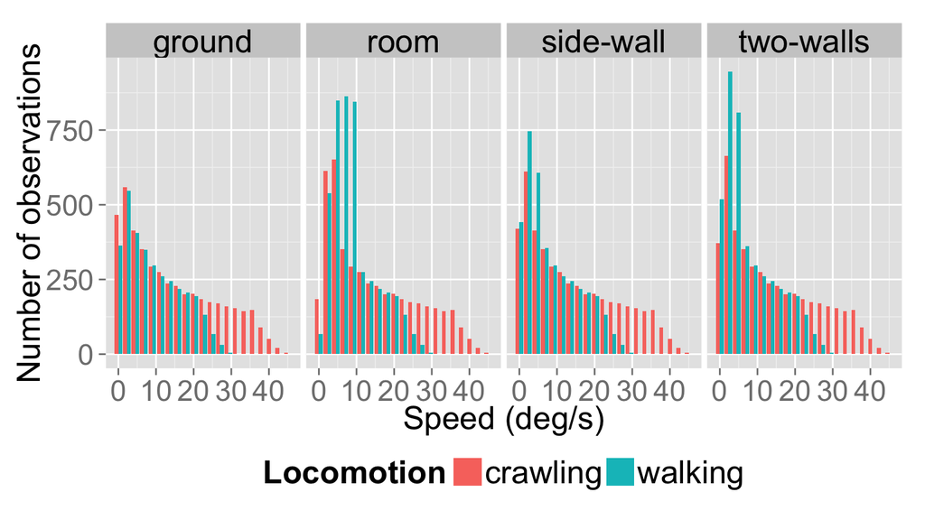

\(\chi^2(20)\): ground: 920.8292078, room: 1476.1183605, side-wall: 958.7145051, and two-walls: 1110.3179808.

## Mean Simulated Flow Speeds By Posture and Geometry

| Type of Locomotion | Ground Plane | Room | Side Wall | Two Walls |
| --- | --- | --- | --- | --- |
| Crawling | 14.41 | 14.42 | 14.43 | 14.62 |
| Walking | 9.38 | 8.56 | 7.39 | 9.18 |

## Empirical Measurements of Optic Flow

- First-person videos from head-mounted cameras
- 20 infants, 41 days to 13.2 mos
- Chennai, India & Bloomington, Indiana
- Data: http://databrary.org/volume/81

## Cultural Differences in Segment Durations

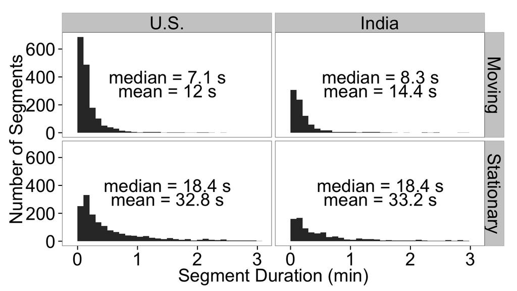

## Segment Durations

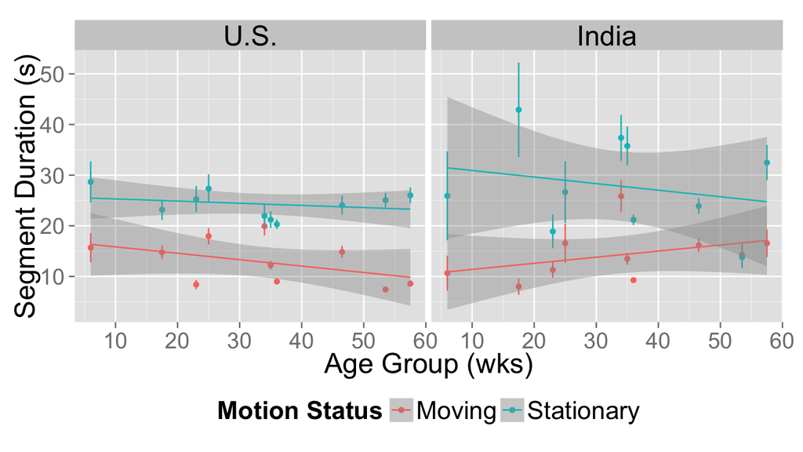

## Normalized Durations as \(p\)(total-time)

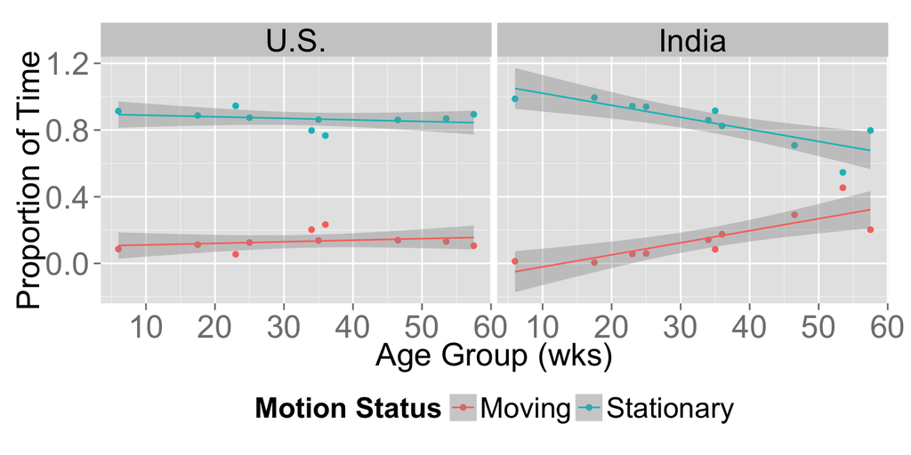

## Natural Scene Statistics for Optic Flow

- Selected 10 5 s segments/participant, both moving and stationary
- Estimated frame by frame flow fields
- Details in [Raudies & Gilmore 2014](http://www.mitpressjournals.org/doi/abs/10.1162/NECO_a_00645#.Va6g-hNViko)

## Speed Distributions

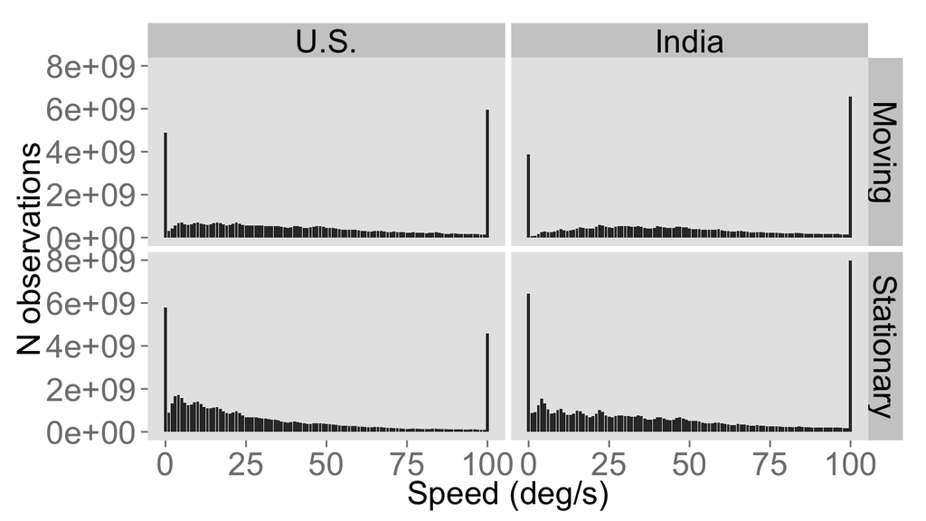

## Comparing Shapes of (Trimmed) Speed Distributions

- Fit \(\gamma\) distribution to trimmed (0,100) speed histograms

\(f(x;k,\theta) = \alpha\frac{x^{k-1}e^{-\frac{x}{\theta}}}{\theta^k\Gamma(k)}\)

\(\alpha\), amplitude; \(\kappa\), shape; and \(\theta\), scale parameters.

## Illustrative Speed Histograms – 6 weeks

[figure not shown]

## Illustrative Speed Histograms – 34 weeks

[figure not shown]

## Illustrative Speed Histograms – 58 weeks

[figure not shown]

## Fitted \(\kappa\) Parameters

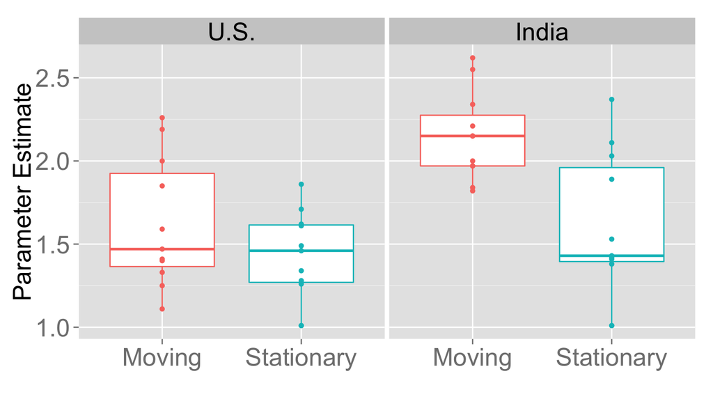

## Fitted \(\alpha\) Parameters

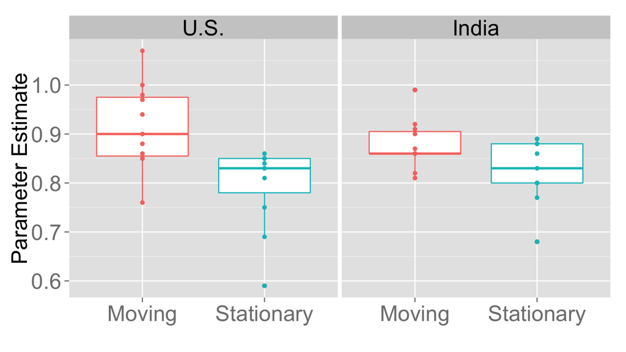

## Fitted \(\theta\) Parameters

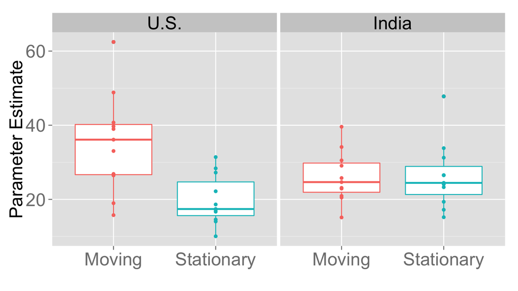

## Summary: Empirical Flow Speed Effects

- Fast speeds (> 100 deg/s) common
- Moving ≠ Stationary
- Broad distribution: \(\kappa\), \(\alpha\)(moving) > \(\kappa\), \(\alpha\)(stationary)
- U.S. ~ India

## Empirical Pattern Distributions

- Correlation with 'canonical' flow patterns
- radial
- rotational
- translational

## Pattern Correlation Results

[figure not shown]

## Pattern Correlation Results by Country

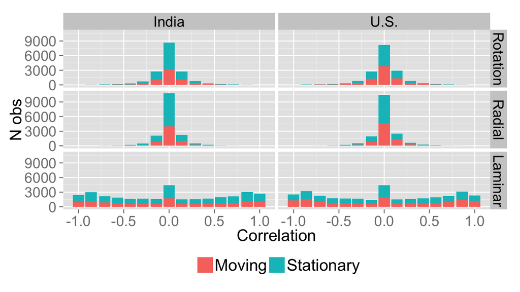

## Conclusions: Simulation

- Posture influences optic flow speeds & patterns
  - Crawling: faster speeds, more translational flow
  - Proximity to ground and pitch of head
  - Geometry matters relatively little

## Conclusions: Empirical Data

- Time stationary >> time in motion
- Time stationary declines with age (India)
- Fast speeds, broad speed distributions
- Individual differences in moving vs. stationary speed distributions
- Laminar flow >> radial or rotational flow, especially when stationary
- **Replicates and extends Raudies & Gilmore '12, '14**

## Summmary of Findings

- Children's brain responses to optic flow are adult-like in many respects
- Adults' are most sensitive to slow, radial flow patterns.
- Infants commonly experience fast, laminar flows.
- Statistics of visual input may shape developmental transition from fast laminar to slow radial flow.

## Stack

- RStudio, https://www.rstudio.com/
  - R Markdown, http://rmarkdown.rstudio.com/
- GitHub, http://github.com/gilmore-lab/, http://github.com/psu-psychology/cognitive-area
- Databrary, https://nyu.databrary.org/volume/81
  - Access to identifiable data (e.g. videos) restricted
  - Access agreement + institutional authorization
- Datayvu, http://datavyu.org
- Matlab

## References

Collaboration, Open Science. 2015. “Estimating the Reproducibility of Psychological Science.” *Science* 349 (6251): aac4716. doi:10.1126/science.aac4716.

Deevybee. 2015. “BishopBlog: Publishing Replication Failures: Some Lessons from History.” *BishopBlog*. http://deevybee.blogspot.com/2015/07/publishing-replication-failures-some.html.

Fesi, Jeremy D., Amanda L. Thomas, and Rick O. Gilmore. 2014. “Cortical Responses to Optic Flow and Motion Contrast Across Patterns and Speeds.” *Vision Research* 100 (July): 56–71. doi:10.1016/j.visres.2014.04.004.

Frank, Michael. 2015. “Babies Learning Language: The Slower, Harder Ways to Increase Reproducibility.” *Babies Learning Language*. http://babieslearninglanguage.blogspot.com/2015/08/the-slower-harder-ways-to-increase.html.

Gilmore, Rick O., C. Hou, M.W. Pettet, and A.M. Norcia. 2007. “Development of Cortical Responses to Optic Flow.” *Visual Neuroscience* 24 (06): 845–56. doi:10.1017/S0952523807070769.

Hou, C., R.O. Gilmore, M.W. Pettet, and A.M. Norcia. 2009. “Spatio-Temporal Tuning of Coherent Motion Evoked Responses in 4–6 Month Old Infants and Adults.” *Vision Research* 49 (20): 2509–17. doi:10.1016/j.visres.2009.08.007.

Jouen, François, Jean-Claude Lepecq, Olivier Gapenne, and Bennett I Bertenthal. 2000. “Optic Flow Sensitivity in Neonates.” *Infant Behavior and Development* 23 (3–4): 271–84. doi:10.1016/S0163-6383(01)00044-3.

Kiorpes, Lynne, and J. Anthony Movshon. 2004. “Development of Sensitivity to Visual Motion in Macaque Monkeys.” *Visual Neuroscience* 21 (6): 851–59. doi:10.1017/S0952523804216054.

Nosek, B. A., G. Alter, G. C. Banks, D. Borsboom, S. D. Bowman, S. J. Breckler, S. Buck, et al. 2015. “Promoting an Open Research Culture.” *Science* 348 (6242): 1422–25. doi:10.1126/science.aab2374.

Raudies, F., R.O. Gilmore, K.S. Kretch, J.M. Franchak, and K.E. Adolph. 2012. “Understanding the Development of Motion Processing by Characterizing Optic Flow Experienced by Infants and Their Mothers.” In *2012 IEEE International Conference on Development and Learning and Epigenetic Robotics (ICDL)*, 1–6. doi:10.1109/DevLrn.2012.6400584.

Raudies, Florian, and Rick O. Gilmore. 2014. “Visual Motion Priors Differ for Infants and Mothers.” *Neural Computation* 26 (11): 2652–68. doi:10.1162/NECO_a_00645.